# Algorithm

Algorithm

8. Intractability I

WU Xiaokun 吴晓堃

xkun.wu [at] gmail

2021/11/19

# Polynomial-Time Reductions

## Design patterns and anti-patterns

Algorithm design patterns.

- Greedy. Divide and conquer. Dynamic programming.
- Duality.
- Reductions.
- Special structure. Approximation. Local search.
- Randomization.

Algorithm design anti-patterns.

- NP-completeness. $O(n^k)$ algorithm unlikely.
- PSPACE-completeness. $O(n^k)$ certification algorithm unlikely.
- Undecidability. No algorithm possible.

## Recap: Efficiency

**Q**. Which problems will we be able to solve in practice?  
**A working definition**. Those with poly-time algorithms.

**Theory**. Definition is broad and robust.  
**Practice**. Poly-time algorithms scale to huge problems.

## Conceptual: Classify problems

**Idea**. Classify problems: can be solved in poly-time and those that cannot.

**Provably requires exponential time**.

- Given a constant-size program, does it halt in at most $k$ steps?
- Given a board game of $n$-by-$n$ checkers, can black guarantee a win?

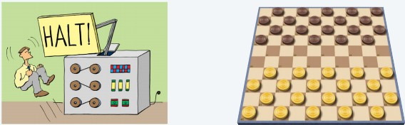

**Frustrating news**. Huge number of fundamental problems have defied classification for decades.

## Practical: Poly-time reductions

**Idea**. Suppose we could solve problem Y in polynomial time. What else could we solve in polynomial time?

**Reduction**. Problem $X$ **polynomial-time reduces to** problem $Y$ if arbitrary instances of problem $X$ can be solved using:

- Polynomial number of standard computational steps, *plus*
- Polynomial number of calls to “oracle” that solves problem $Y$.

**Notation**. $X \le_P Y$.

**Note**. We pay for time to write down instances of $Y$ sent to oracle $\Rightarrow$ instances of $Y$ must be of polynomial *size*.

**Common mistake**. Confusing $X \le_P Y$ with $Y \le_P X$.

## Quiz: $X \le_P Y$

Suppose that $X \le_P Y$. Which of the following can we infer?

**A**. If $X$ can be solved in polynomial time, then so can $Y$.  
**B**. $X$ can be solved in poly time iff $Y$ can be solved in poly time.  
**C**. If $X$ cannot be solved in polynomial time, then neither can $Y$.  
**D**. If $Y$ cannot be solved in polynomial time, then neither can $X$.

C. contrapositive

## Poly-time reductions

**Design algorithms**. If $X \le_P Y$ and $Y$ can be solved in polynomial time, then $X$ can be solved in polynomial time.

**Establish intractability**. If $X \le_P Y$ and $X$ cannot be solved in polynomial time, then $Y$ cannot be solved in polynomial time.

**Establish equivalence**. If both $X \le_P Y$ and $Y \le_P X$, we use notation $X \equiv_P Y$.

- In this case, $X$ can be solved in polynomial time iff $Y$ can be.

**Bottom line**. Reductions classify problems according to relative difficulty.

# Packing and covering

## Independent set

**INDEPENDENT-SET**. Given a graph $G = (V, E)$ and an integer $k$, is there a subset of $k$ (or more) vertices such that no two are adjacent?

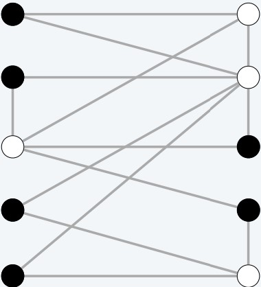

**Optimization**: [Packing] What is the maximum size independent set?

## Vertex cover

**VERTEX-COVER**. Given a graph $G = (V, E)$ and an integer $k$, is there a subset of $\le k$ vertices that each edge is incident to at least one vertex in the subset?

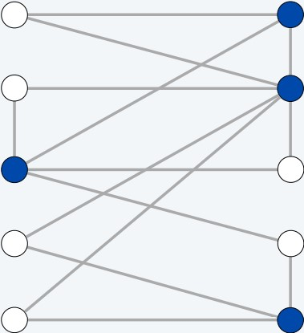

**Optimization**: [Covering] What is the minimum size vertex cover?

## Packing $\equiv_P$ Covering

**Theorem**. INDEPENDENT-SET $\equiv_P$ VERTEX-COVER.  
**Pf**. We show $S$ is an independent set of size $k$ iff $V - S$ is a vertex cover of size $n - k$.

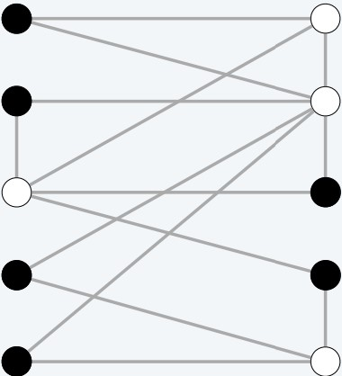

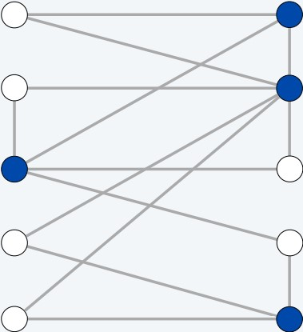

## Packing $\equiv_P$ Covering: $\Rightarrow$

**Theorem**. INDEPENDENT-SET $\equiv_P$ VERTEX-COVER.  
**Pf**. We show $S$ is an independent set of size $k$ iff $V - S$ is a vertex cover of size $n - k$.

- Let $S$ be any independent set of size $k$.
  - $V - S$ is of size $n - k$.
- Consider an arbitrary edge $(u, v) \in E$.
  - $S$ independent $\Rightarrow$ either $u \notin S$, or $v \notin S$, or both.
  - $\Rightarrow$ either $u \in V - S$, or $v \in V - S$, or both.
  - Thus, $V - S$ covers $(u, v)$.
- $\Rightarrow$ VERTEX-COVER $\le_P$ INDEPENDENT-SET.

## Packing $\equiv_P$ Covering: $\Leftarrow$

**Theorem**. INDEPENDENT-SET $\equiv_P$ VERTEX-COVER.  
**Pf**. We show $S$ is an independent set of size $k$ iff $V - S$ is a vertex cover of size $n - k$.

- Let $V - S$ be any vertex cover of size $n - k$.
  - $S$ is of size $k$.
- Consider an arbitrary edge $(u, v) \in E$.
  - $V - S$ is a vertex cover $\Rightarrow$ either $u \in V - S$, or $v \in V - S$, or both.
  - $\Rightarrow$ either $u \notin S$, or $v \notin S$, or both.
- Thus, $S$ is an independent set.
- $\Rightarrow$ INDEPENDENT-SET $\le_P$ VERTEX-COVER.

## Set cover

**SET-COVER**. Given a set $U$ of elements, a collection $S$ of subsets of $U$, and an integer $k$, are there $\le k$ of these subsets whose union is equal to $U$?

**Sample application**. software-services.

|  | 1 | 2 | 3 | 4 | 5 | 6 | 7 |
| --- | --- | --- | --- | --- | --- | --- | --- |
| A |  |  | + |  |  |  |  |
| B |  | + |  | + |  |  |  |
| C |  |  | + | + | + | + |  |
| D |  |  |  |  | + |  |  |
| E | + |  |  |  |  |  |  |
| F | + | + |  |  |  | + | + |

## Vertex Cover $\le_P$ Set Cover

**Theorem**. VERTEX-COVER $\le_P$ SET-COVER.  
**Pf**. Given a VERTEX-COVER instance $G = (V, E)$ and $k$, we construct a SET-COVER instance $(U, S, k)$ that has a set cover of size $k$ iff $G$ has a vertex cover of size $k$.

**Construction**.

- Universe $U = E$.
- Include one subset for each node $v \in V : S_v = \{e \in E : e\ \text{incident to}\ v \}$.

## Vertex Cover $\le_P$ Set Cover: Lemma

**Lemma**. $G = (V, E)$ contains a vertex cover of size $k$ iff $(U, S, k)$ contains a set cover of size $k$.  
**Pf**. $\Rightarrow$ Let $X \subseteq V$ be a vertex cover of size $k$ in $G$.

- Then $Y = { S_v : v \in X }$ is a set cover of size $k$.

## Vertex Cover $\le_P$ Set Cover: Lemma (cont.)

**Lemma**. $G = (V, E)$ contains a vertex cover of size $k$ iff $(U, S, k)$ contains a set cover of size $k$.  
**Pf**. $\Leftarrow$ Let $Y \subseteq S$ be a set cover of size $k$ in $(U, S, k)$.

- Then $X = { v : S_v \in Y }$ is a vertex cover of size $k$ in $G$.

# Constraint satisfaction

## Recap: Conjunctive normal form (CNF)

**Literal**. A Boolean variable or its negation: $x_i, \bar{x_i}$.

**Clause**. A *disjunction* of literals: eg., $C_j = x_1 \vee \bar{x_2} \vee x_3$.

**Conjunctive normal form (CNF)**. A propositional formula $\Phi$ that is a *conjunction* of clauses: eg., $\Phi = C_1 \wedge C_2 \wedge C_3$.

## Satisfiability

**SAT**. Given a CNF formula $\Phi$, does it have a satisfying *truth assignment*?

**3-SAT**. SAT where each clause contains exactly 3 literals (and each literal corresponds to a different variable).

- yes instance: $x_1 = 1, x_2 = 1, x_3 = 0, x_4 = 0$

**Key application**. Electronic design automation (EDA).

## Satisfiability is hard

**Scientific hypothesis**. There does not exist a poly-time algorithm for 3-SAT.

**$\mathcal{P}$ vs. $\mathcal{NP}$**. This hypothesis is equivalent to $\mathcal{P} \ne \mathcal{NP}$ conjecture.

[figure not shown]

## 3-SAT $\le_P$ INDEPENDENT-SET

**Theorem**. 3-SAT $\le_P$ INDEPENDENT-SET.  
**Pf**. Given a 3-SAT instance $\Phi$, we construct a INDEPENDENT-SET instance $(G, k)$ that has a size $k = |\Phi|$ independent set iff $\Phi$ is satisfiable.

**Construction**.

- $G$ contains 3 nodes for each clause, one for each literal.
- Connect 3 literals in a clause in a triangle.
- Connect literal to each of its negations.

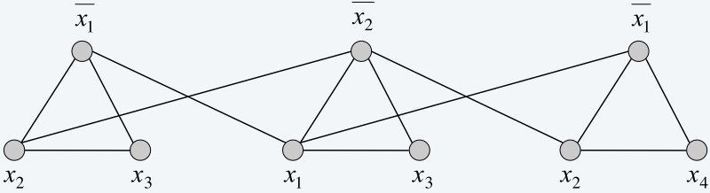

## 3-SAT $\le_P$ INDEPENDENT-SET: Lemma

**Lemma**. $\Phi$ is satisfiable iff $G$ contains an independent set of size $k = |\Phi|$.  
**Pf**. $\Rightarrow$ Consider any satisfying assignment for $\Phi$.

- Select one true literal from each clause/triangle.
- This is an independent set of size $k = |\Phi|$.

## 3-SAT $\le_P$ INDEPENDENT-SET: Lemma

**Lemma**. $\Phi$ is satisfiable iff $G$ contains an independent set of size $k = |\Phi|$.  
**Pf**. $\Leftarrow$ Let $S$ be independent set of size $k$.

- $S$ must contain exactly one node in each triangle.
- Set these literals to `true` (and remaining literals consistently).
- All clauses in $\Phi$ are satisfied.

## Review

**Basic reduction strategies**.

- Simple equivalence: INDEPENDENT-SET $\equiv_P$ VERTEX-COVER.
- Special case to general case: VERTEX-COVER $\le_P$ SET-COVER.
- Encoding with gadgets: 3-SAT $\le_P$ INDEPENDENT-SET.

**Transitivity**. If $X \le_P Y$ and $Y \le_P Z$, then $X \le_P Z$.  
**Pf idea**. Compose those two algorithms.

**Ex**. 3-SAT $\le_P$ INDEPENDENT-SET $\equiv_P$ VERTEX-COVER $\le_P$ SET-COVER.

## Decision, Search, Optimization

**Decision problem**. Does there exist a vertex cover of size $\le k$?

**Search problem**. Find a vertex cover of size $\le k$.

**Optimization problem**. Find a vertex cover of minimum size.

**Goal**. Show that all three problems poly-time reduce to one another.

## Decision vs. Search

**VERTEX-COVER**. Does there exist a vertex cover of size $\le k$?  
**FIND-VERTEX-COVER**. Find a vertex cover of size $\le k$.

**Theorem**. VERTEX-COVER $\equiv_P$ FIND-VERTEX-COVER.

**Pf. $\le_P$** Decision problem is a special case of search problem.

**Pf. $\ge_P$** To find a vertex cover of size $\le k$:

- Determine if there exists a vertex cover of size $\le k$.
- Enumerate $V$ and find a vertex $v$ that $G - \{ v \}$ has a vertex cover of size $\le k - 1$. (any vertex in any vertex cover of size $\le k$ will suffice)
- Include $v$ in the vertex cover.
- Recursively find a vertex cover of size $\le k - 1$ in $G - \{ v \}$.

## Search vs. Optimization

**FIND-VERTEX-COVER**. Find a vertex cover of size $\le k$.  
**FIND-MIN-VERTEX-COVER**. Find a vertex cover of minimum size.

**Theorem**. FIND-VERTEX-COVER $\equiv_P$ FIND-MIN-VERTEX-COVER.

**Pf. $\le_P$** Search problem is a special case of optimization problem.

**Pf. $\ge_P$** To find vertex cover of minimum size:

- Binary search (or linear search) for size $k^\ast$ of min vertex cover.
- Solve search problem for given $k^\ast$.

# Sequencing problems

## Hamilton cycle

**HAM-CYCLE**. Given an undirected graph $G = (V, E)$, does there exist a cycle $\Gamma$ that visits every node exactly once?

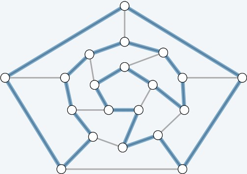

**Sequencing Problems**. Search over all *permutations* of a collection of objects.

- Ex. Traveling Salesman Problem.
  - missing ordering?

## Directed Hamilton cycle

**DIR-HAM-CYCLE**. Given a directed graph $G = (V, E)$, does there exist a directed cycle $\Gamma$ that visits every node exactly once?

**Theorem**. DIR-HAM-CYCLE $\le_P$ HAM-CYCLE.  
**Pf**. Given a directed graph $G = (V, E)$, construct a graph $G'$ with $3n$ nodes.

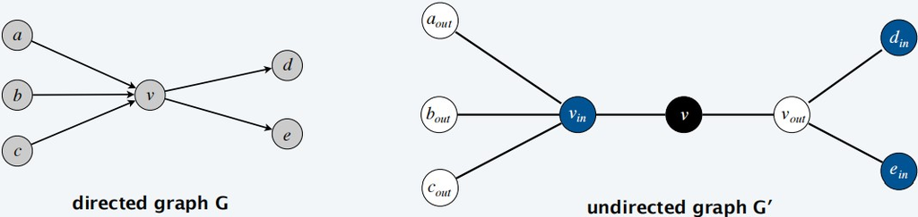

## DIR-HAM-CYCLE $\le_P$ HAM-CYCLE

**Lemma**. $G$ has a directed Hamilton cycle iff $G'$ has a Hamilton cycle.

**Pf. $\Rightarrow$**

- Suppose $G$ has a directed Hamilton cycle $\Gamma$.
- Then $G'$ has an undirected Hamilton cycle (same order).

**Pf. $\Leftarrow$**

- Suppose $G'$ has an undirected Hamilton cycle $\Gamma'$.
- $\Gamma'$ must visit nodes in $G'$ using one of following two reverse orders:
  - $\ldots, B, K, W, B, K, W, B, K, W, \ldots$
  - $\ldots, W, K, B, W, K, B, W, K, B, \ldots$
- Black nodes in $\Gamma'$ comprise either a directed Hamilton cycle $\Gamma$ in $G$, or reverse of one.

## 3-SAT $\le_P$ DIR-HAM-CYCLE

**Theorem**. 3-SAT $\le_P$ DIR-HAM-CYCLE.  
**Pf**. Given an instance $\Phi$ of 3-SAT, we construct an instance $G$ of DIR-HAM-CYCLE that has a Hamilton cycle iff $\Phi$ is satisfiable.

## Construction: variable

**Construction**. Given 3-SAT instance $\Phi$ with $n$ variables $x_i$ and $k$ clauses.

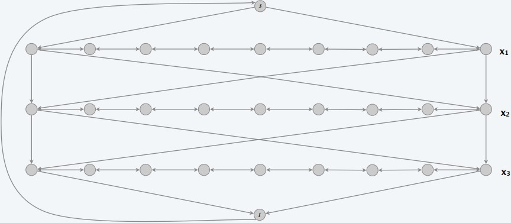

## Quiz: DIR-HAM-CYCLE

Which is truth assignment corresponding to Hamilton cycle below?

- $x_1$ = `true`, $x_2$ = `true`, $x_3$ = `true`
- $x_1$ = `true`, $x_2$ = `true`, $x_3$ = `false`
- $x_1$ = `false`, $x_2$ = `false`, $x_3$ = `true`
- $x_1$ = `false`, $x_2$ = `false`, $x_3$ = `false`

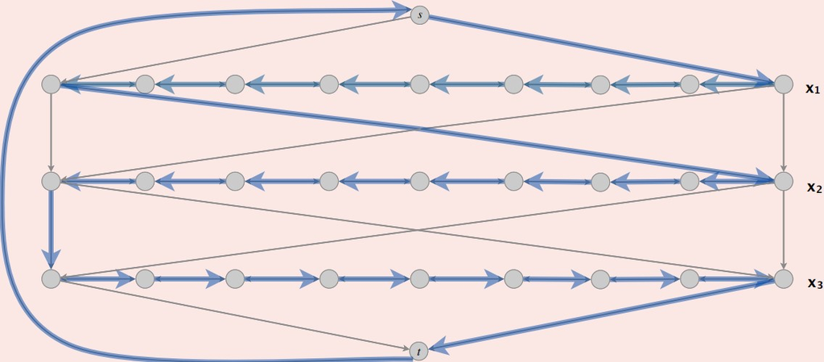

## Construction: clause

**Construction**. Given 3-SAT instance $\Phi$ with $n$ variables $x_i$ and $k$ clauses.

- For each clause: add a node and 2 edges per literal.

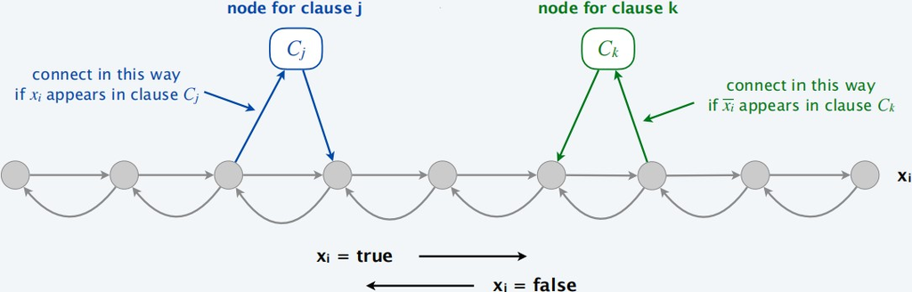

**Construction**. Given 3-SAT instance $\Phi$ with $n$ variables $x_i$ and $k$ clauses.

- For each clause: add a node and 2 edges per literal.

## 3-SAT $\le_P$ DIR-HAM-CYCLE: Lemma

**Lemma**. $\Phi$ is satisfiable iff $G$ has a Hamilton cycle.  
**Pf**. $\Rightarrow$

- Suppose 3-SAT instance $\Phi$ has satisfying assignment $x^\ast$.
- Then, define Hamilton cycle $\Gamma$ in $G$ as follows:
- for each variable $x^\ast_i$,
  - if $x^\ast_i$ = `true`, traverse row $i$ from left to right
  - if $x^\ast_i$ = `false`, traverse row $i$ from right to left
- for each clause $C_j$,
  - at least one row $i$ in which we are going in “correct” direction
  - splice clause node $C_j$ into cycle (and splice $C_j$ exactly once)

## 3-SAT $\le_P$ DIR-HAM-CYCLE: Lemma

**Lemma**. $\Phi$ is satisfiable iff $G$ has a Hamilton cycle.  
**Pf**. $\Leftarrow$

- Suppose $G$ has a Hamilton cycle $\Gamma$.
- If $\Gamma$ enters clause node $C_j$, it must depart on a parallel (variable) edge.
  - nodes neighbor to $C_j$ are connected by an edge $e \in E$
- remove $C_j$ from cycle, and replace it with edge $e$ yields Hamilton cycle on $G - \{ C_j \}$
  - Continuing in this way, we are left with a Hamilton cycle $\Gamma'$ in $G - \{ C_1 , C_2 , \ldots, C_k \}$.
- Set $x^\ast_i$ = `true` if $\Gamma'$ traverses row $i$ left-to-right; otherwise, set $x^\ast_i$ = `false`.
- traversed in “correct” direction, and each clause is satisfied.

## Poly-time reductions: review I

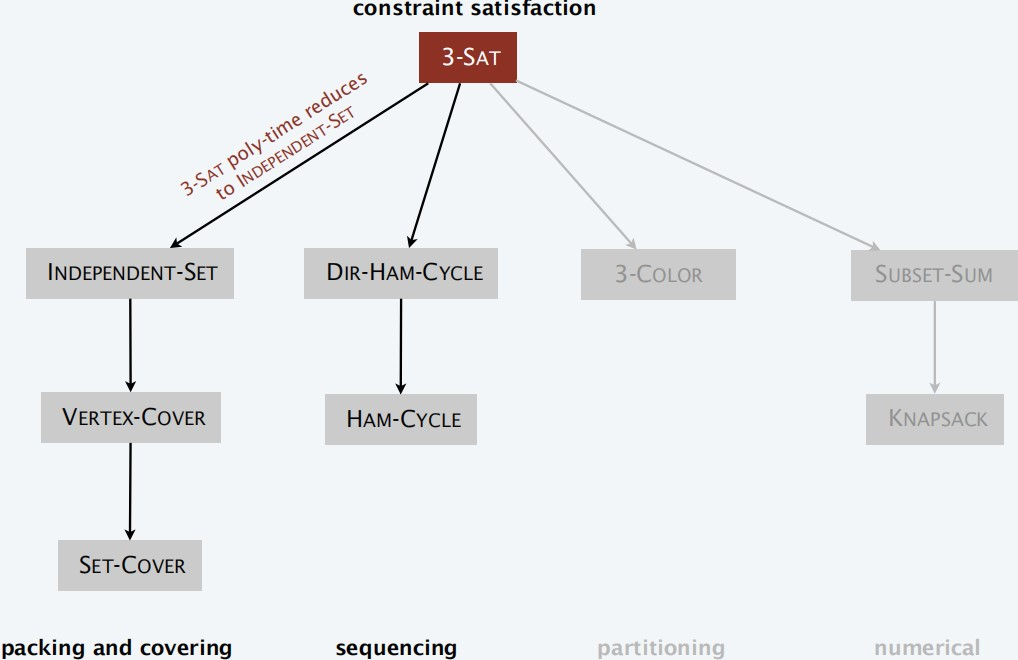

# Partitioning problems

## 3-dimensional matching

`3D-MATCHING`. Given $n$ instructors, $n$ courses, and $n$ times, and a list of the possible courses and times each instructor is willing to teach, is it possible to make an assignment so that all courses are taught at different times?

**Ex**. Three courses, Mon.-Wed. afternoon.

| I | M | T | W |
| --- | --- | --- | --- |
| A |  |  | AI, **AD** |
| B | AI | **AI**, SE |  |
| C | AI, **SE** |  | SE |

{A, AD, W}, {B, AI, T}, {C, SE, M}

## 3D-MATCHING

**3D-MATCHING**. Given $3$ disjoint sets $X, Y, Z$, each of size $n$ and a set $T \subseteq X \times Y \times Z$ of triples, does there exist a set of $n$ triples in $T$ such that each element of $X \cup Y \cup Z$ is in *exactly one* of these triples?

**Remark**. Generalization of bipartite matching.

- each element of $X \cup Y$ is in *exactly one* of $X \times Y$

**Theorem**. 3-SAT $\le_P$ 3D-MATCHING.  
**Pf**. Given an instance $\Phi$ of 3-SAT, we construct an instance of 3D-MATCHING that has a perfect matching iff $\Phi$ is satisfiable.

## Constructing gadget: variable

**Construction**. (variable)

- Create gadget for each variable $x_i$ with $2k$ *core* elements and $2k$ *tip* ones.
  - $k$: number of clauses, or triplets.
  - tip: assignment of one variable.
  - core: one pair in some triplet.

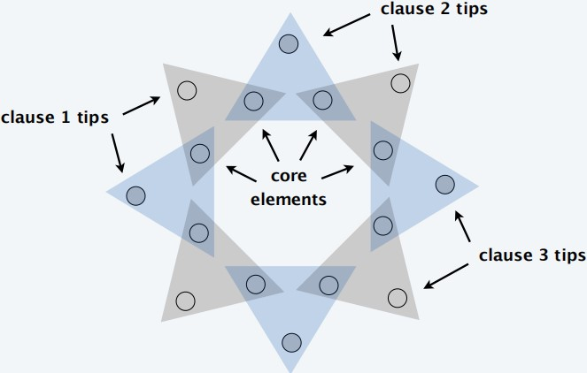

## Constructing gadget: variable (cont.)

**Construction**. (variable)

- Create gadget for each variable $x_i$ with $2k$ *core* elements and $2k$ *tip* ones.
  - A perfect matching will not use overlapping core elements.
    - In gadget for $x_i$, must use either all gray triples (*even*: $x_i$ = `true`) or all blue ones (*odd*: $x_i$ = `false`).
  - Or view from tips: two possible choices.

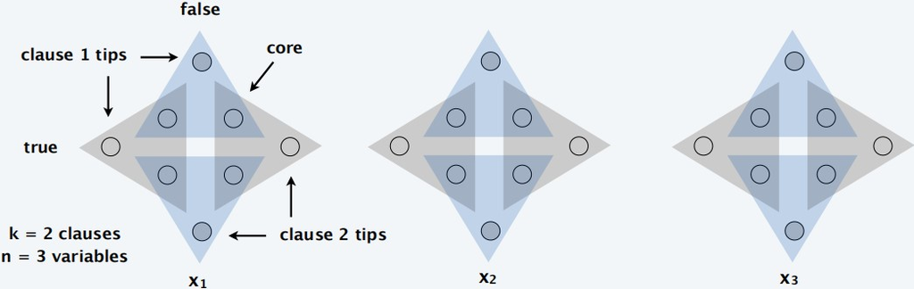

## Constructing gadget: clause

**Construction**. (clause)

- Create gadget for each clause $C_j$ with two *core* elements and three triples.
  - *Exactly one* of these triples will be used in any 3d-matching.
    - Ensures example perfect matching uses either: (i) grey core of $x_1$ or (ii) blue core of $x_2$ or (iii) grey core of $x_3$.
  - *Opposite* to truth assignment of variables.

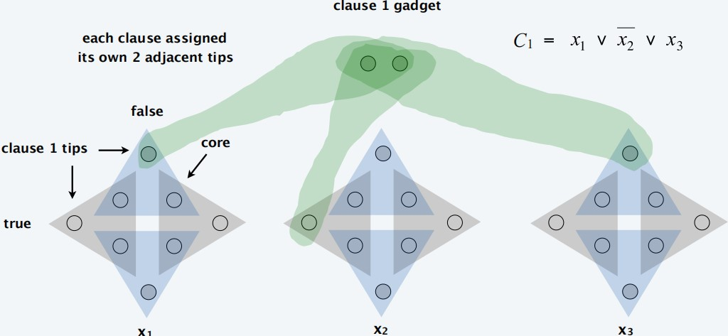

## Constructing gadget: cleanup

**Construction**. (cleanup)

- There are $2 n k$ tips: $n k$ covered by blue/gray triples; $k$ by clause triples.
- To cover remaining $(n – 1) k$ tips, create $(n – 1) k$ “cleanup” gadgets: same as clause gadget but with $2 n k$ triples, connected to *every* tip.

## 3-SAT $\le_P$ 3D-MATCHING

**Lemma**. Instance $(X, Y, Z)$ has a perfect matching iff $\Phi$ is satisfiable.

**Q**. What are $X$, $Y$, and $Z$?

## 3-SAT $\le_P$ 3D-MATCHING (cont.)

**Lemma**. Instance $(X, Y, Z)$ has a perfect matching iff $\Phi$ is satisfiable.

**Q**. What are $X$, $Y$, and $Z$?  
**A**. $X$ = `black`, $Y$ = `white`, and $Z$ = `blue`.

## 3-SAT $\le_P$ 3D-MATCHING: proof

**Lemma**. Instance $(X, Y, Z)$ has a perfect matching iff $\Phi$ is satisfiable.

**Pf**. $\Rightarrow$ If 3d-matching, then assign $x_i$ according to gadget $x_i$.

**Pf**. $\Leftarrow$ If $\Phi$ is satisfiable, use any true literal in $C_j$ to select gadget $C_j$ triple.

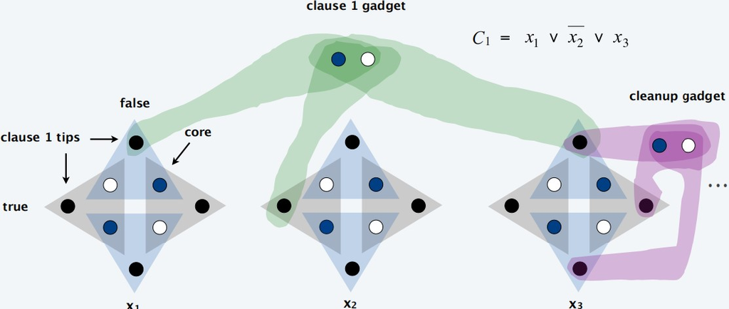

# Graph coloring

## 3-colorability

**3-COLOR**. Given an undirected graph $G$, can the nodes be colored `black`, `white`, and `blue` so that no adjacent nodes have the same color?

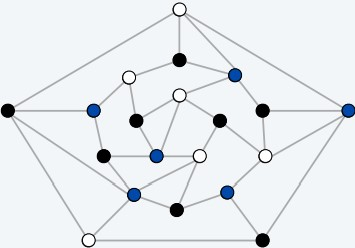

## Quiz: 2-COLOR

How difficult to solve 2-COLOR?

**A**. $O(m + n)$ using BFS or DFS.  
**B**. $O(mn)$ using maximum flow.  
**C**. $\Omega(2^n)$ using brute force.  
**D**. Not even Tarjan knows.

A graph G is 2-colorable if and only if it is bipartite.

- so, $O(m + n)$
- see Section 3.4

## Application: register allocation

**Register allocation**. Assign program variables to machine registers so that: (i) no more than $k$ registers are used, (ii) and no two program variables that are needed at the same time are assigned to the same register.

**Interference graph**. Nodes are program variables; edge between $u$ and $v$ if there exists an operation where both $u$ and $v$ are “live” at the same time.

**Observation**. [Chaitin 1982] Can solve register allocation problem iff interference graph is $k$-colorable.

**Fact**. 3-COLOR $\le_P$ K-REGISTER-ALLOCATION for any constant $k \ge 3$.

## 3-SAT $\le_P$ 3-COLOR

**Theorem**. 3-SAT $\le_P$ 3-COLOR.

**Pf**. Given 3-SAT instance $\Phi$, we construct an instance of 3-COLOR that is 3-colorable iff $\Phi$ is satisfiable.

- Intuition: see the following graph which is not 3-colorable.

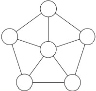

## 3-SAT $\le_P$ 3-COLOR: Construction

**Construction**.

1. Create a graph $G$ with a node for each literal.
2. Connect each literal to its negation.
3. Create 3 new nodes $T$, $F$, and $B$; connect them in a triangle.
4. Connect each literal to $B$.
5. For each clause $C_j$, add a gadget of 6 nodes and 13 edges.

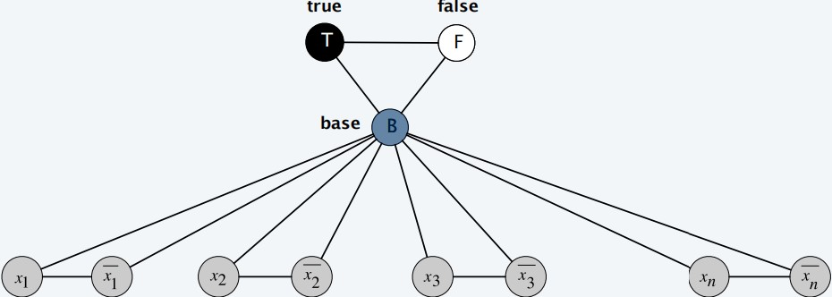

## 3-SAT $\le_P$ 3-COLOR: $\Rightarrow$

**Lemma**. Graph $G$ is 3-colorable iff $\Phi$ is satisfiable.  
**Pf**. $\Rightarrow$ Suppose graph $G$ is 3-colorable.

- WLOG, assume node $T$ is colored `black`, $F$ is `white`, and $B$ is `blue`.
- Consider assignment sets all `black` literals to `true` (and `white` to `false`).
- #4 ensures each literal is colored either `black` or `white`.
- #2 ensures each literal is `white` if its negation is `black` (and vice versa).

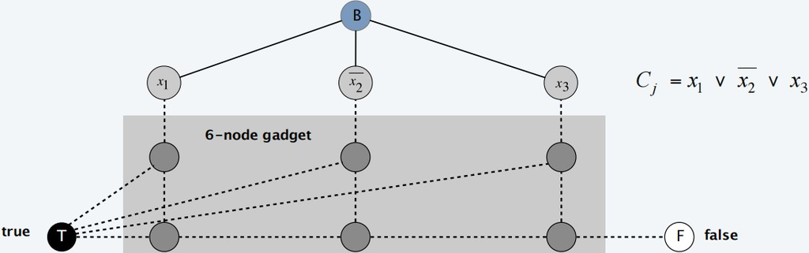

## 3-SAT $\le_P$ 3-COLOR: $\Rightarrow$ (cont.)

**Lemma**. Graph $G$ is 3-colorable iff $\Phi$ is satisfiable.  
**Pf**. $\Rightarrow$ Suppose graph $G$ is 3-colorable.

- #5 ensures at least one literal in each clause is `black`.
  - suppose (for contradiction) all 3 literals are `white` in some 3-coloring
  - then first row must be 3 `blue`,
  - then second row must alternate between `white` & `black`,
    - no possible coloring.

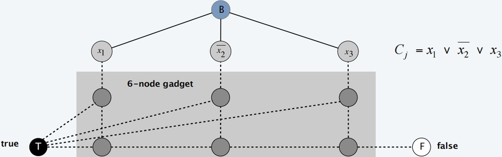

## 3-SAT $\le_P$ 3-COLOR: $\Leftarrow$

**Lemma**. Graph $G$ is 3-colorable iff $\Phi$ is satisfiable.  
**Pf**. $\Leftarrow$ Suppose 3-SAT instance $\Phi$ is satisfiable.

- Color all `true` literals `black` and all `false` literals `white`.
- Pick one `true` literal; color node below that node `white`, and node below that `blue`.
- Color remaining middle row nodes `blue`.
- Color remaining bottom nodes `black` or `white`, as forced.

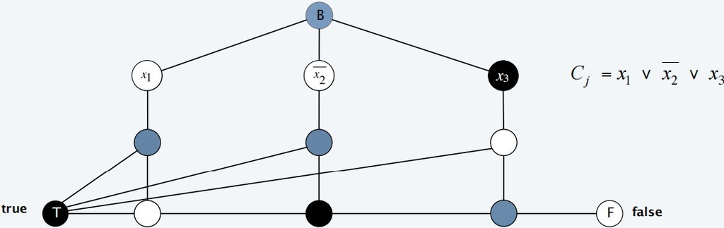

## Poly-time reductions: review II

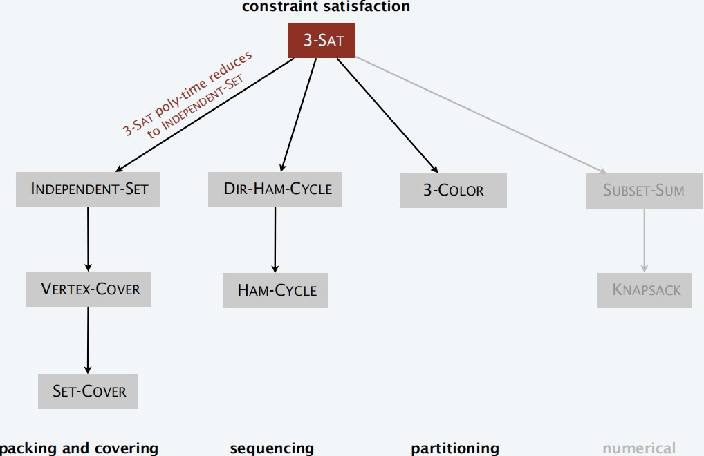

# Numerical problems

## Subset sum

**SUBSET-SUM**. Given $n$ natural numbers $w_1, \ldots, w_n$ and an integer $W$, is there a subset that adds up to exactly $W$?

**Ex**. $\{ 215, 215, 275, 275, 355, 355, 420, 420, 580, 580, 655, 655 \}, W = 1505$.  
**Yes**. $215 + 355 + 355 + 580 = 1505$.

## Why is it a problem?

We solved it using dynamic programming with time $O(nW)$.

**Remark**. With arithmetic problems, input integers are encoded in binary. Poly-time reduction must be polynomial in *binary* encoding.

- problem comes when $W$ is large.
- ex. 100 numbers, each number is 100 bits long:
  - input: $100 \times 100 = 10000$ digits,
  - $W$: roughly $2^{100}$, *exponential* to size of input.

We referred to such problem as **Pseudo-polynomial**.

- ran in time polynomial in the magnitude of the input numbers,
- but not polynomial in the size of their representation.

## 3-SAT $≤_P$ SUBSET-SUM

**Theorem**. 3-SAT $≤_P$ SUBSET-SUM.

**Pf**. Given an instance $\Phi$ of 3-SAT, we construct an instance of SUBSET-SUM that has solution iff $\Phi$ is satisfiable.

## 3-SAT $≤_P$ SUBSET-SUM: construction

**Construction**. Given 3-SAT instance $\Phi$ with $n$ variables and $k$ clauses, form $2n + 2k$ *decimal* integers, each having $n + k$ digits:

- Include one digit for each variable $x_i$ and one digit for each clause $C_j$.
  - two numbers for each variable $x_i$.
  - two numbers for each clause $C_j$.
- Sum of $x_i$ column is 1; sum of $C_j$ column is 4.

**Key property**. No carries possible $\Rightarrow$ each digit yields one equation.

## 3-SAT $≤_P$ SUBSET-SUM: $\Rightarrow$

**Lemma**. $\Phi$ is satisfiable iff there exists a subset that sums to $W$.  
**Pf**. $\Rightarrow$ Suppose 3-SAT instance $\Phi$ has satisfying assignment $x^\ast$.

- If $x^\ast_i$ = `true`, select integer in row $x_i$; otherwise, select integer in row $\neg x_i$.
- Each $x_i$ digit sums to 1.
- Since $\Phi$ is satisfiable, each $C_j$ digit sums to at least 1 from $x_i$ and $\neg x_i$ rows.
- Select dummy integers to make $C_j$ digits sum to 4.

## 3-SAT $≤_P$ SUBSET-SUM: $\Leftarrow$

**Lemma**. $\Phi$ is satisfiable iff there exists a subset that sums to $W$.  
**Pf**. $\Leftarrow$ Suppose there exists a subset $S^\ast$ that sums to $W$.

- Digit $x_i$ forces subset $S^\ast$ to select either row $x_i$ or row $\neg x_i$ (but not both).
- If row $x_i$ selected, assign $x^\ast_i$ = `true`; otherwise, assign $x^\ast_i$ = `false`.
- Digit $Cj$ forces subset $S^\ast$ to select at least one literal in clause.

## Poly-time reductions: review III

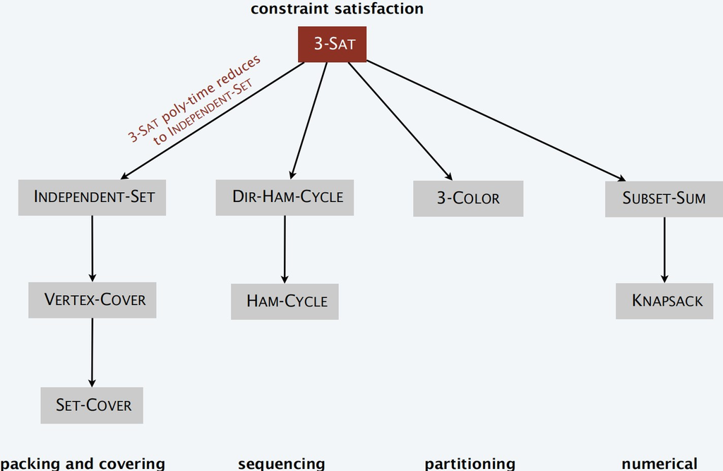

## Karp’s 20 reductions from satisfiability

Karp [1972], 1985 Turing Award.

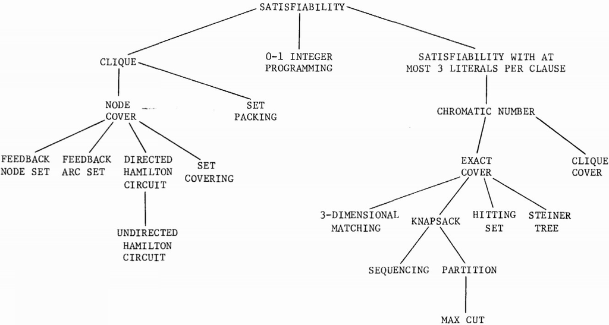